# Reproducible Research: Peer Assessment 1

September 2019

## Loading and preprocessing the data

```r
library(dplyr)
```

```r
activity=read.csv("activity.csv")
```

## What is mean total number of steps taken per day?

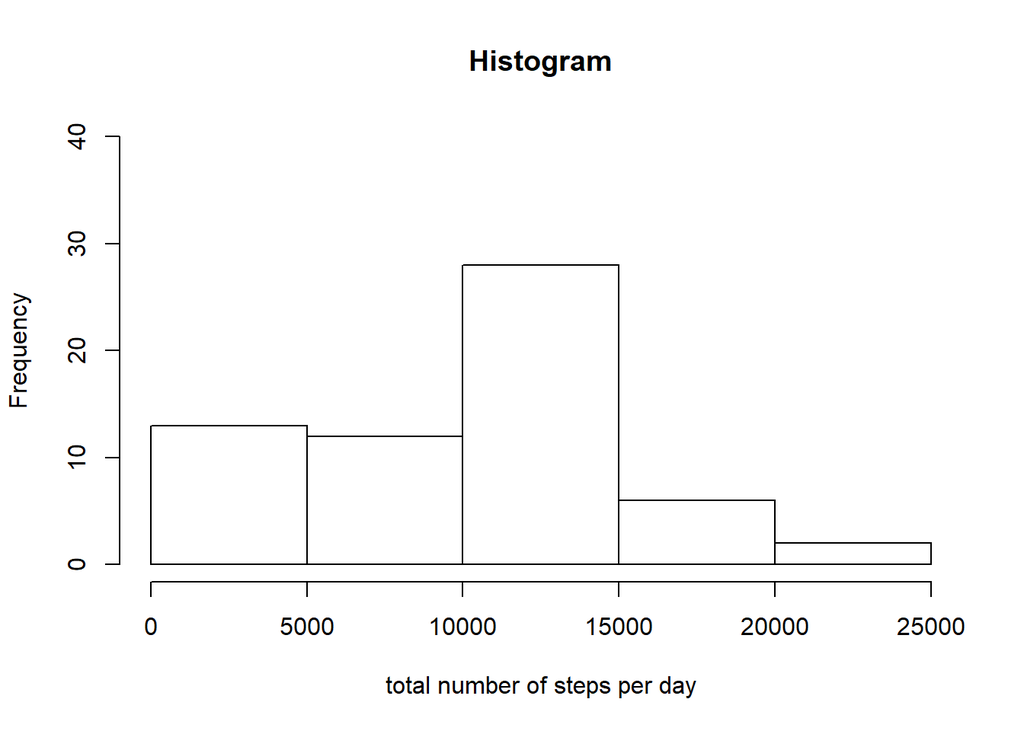

```r
totalstep<-tapply(activity$steps, activity$date, sum, na.rm=TRUE)

hist(totalstep, xlab="total number of steps per day",
main="Histogram",ylim=c(0,40))
```

```r
summary(totalstep)
```

```
##    Min. 1st Qu.  Median    Mean 3rd Qu.    Max.
##       0    6778   10395    9354   12811   21194
```

```r
options(scipen = 999)
options(digits=0)
meanTotStep<-summary(totalstep)[4]
medianTotStep<-summary(totalstep)[3]
```

The mean of the total number of steps taken per day is 9354.

The median of the total number of steps taken per day is 10395.

## What is the average daily activity pattern?

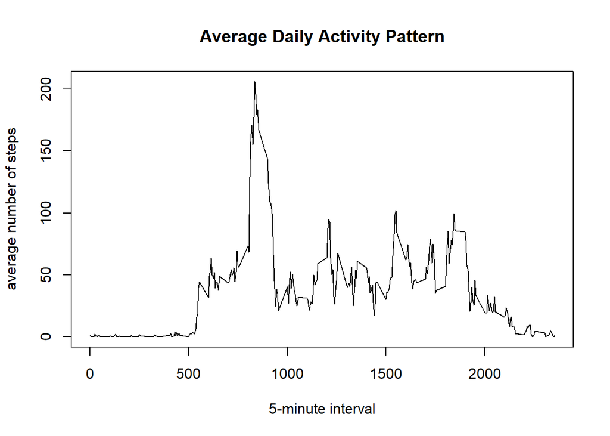

```r
intervalstep<-tapply(activity$steps, as.factor(activity$interval),
mean,na.rm=TRUE)

plot(row.names(intervalstep), intervalstep, type="l",
xlab="5-minute interval", ylab="average number of steps",
main="Average Daily Activity Pattern")
```

```r
intervalMax<-row.names(intervalstep)[which(intervalstep==max(intervalstep))]
```

Interval 835 contains the maximum number of steps.

## Imputing missing values

```r
missingValue<-sum(is.na(activity$steps))
```

The total number of missing values in the dataset is 2304.

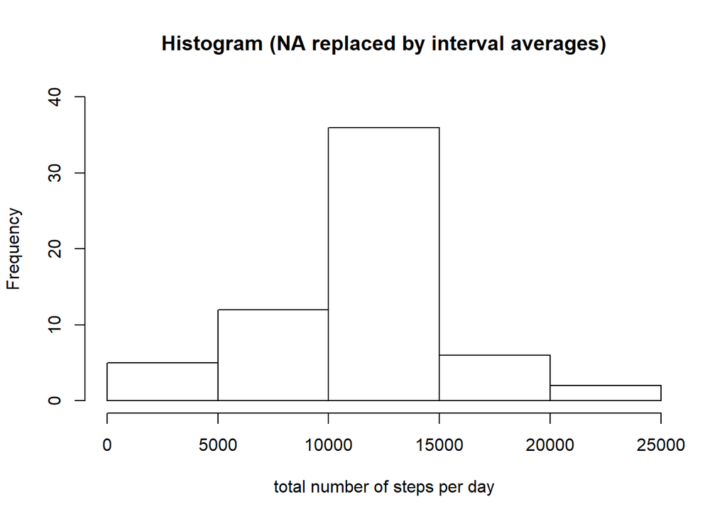

```r
#Place the average number of step in each 5-minute interval across all days in a dataframe

df<-data.frame(interval=row.names(intervalstep), intervalstep)

#subset the activity dataset into two sets, one contains #all the NA rows, the other contains all the non-NA rows

NAset<-subset(activity, is.na(activity$steps))
rmNAset<-subset(activity, !is.na(activity$steps))

#replace the NA values by the average number of step in #each 5-minute interval from dataframe df

NAset$steps<-df$intervalstep[match(NAset$interval, df$interval)]

#recombine the NAset with NA replaced and the non-NA set, #and sort by date

activity2<-arrange(rbind(NAset, rmNAset),date)

totalstep2<-tapply(activity2$steps, activity2$date, sum)
hist(totalstep2, ylim=c(0,40),xlab="total number of steps per day", main="Histogram (NA replaced by interval averages)")
```

```r
summary(totalstep2)
```

```
##    Min. 1st Qu.  Median    Mean 3rd Qu.    Max.
##      41    9819   10766   10766   12811   21194
```

```r
meanTotStep2<-summary(totalstep2)[4]
medianTotStep2<-summary(totalstep2)[3]
```

The mean of the total number of steps taken per day is 10766.

The median of the total number of steps taken per day is 10766.

The medians of the two datasets are similar; the mean is higher in the dataset with NA values replaced with the average number of step of corresponding intervals. This makes sense because inputting values to replace NAs will push the mean up, compared to removing NAs. And most the NAs seem to occur in the 0-5000 and 10000-15000 ranges.

## Are there differences in activity patterns between weekdays and weekends?

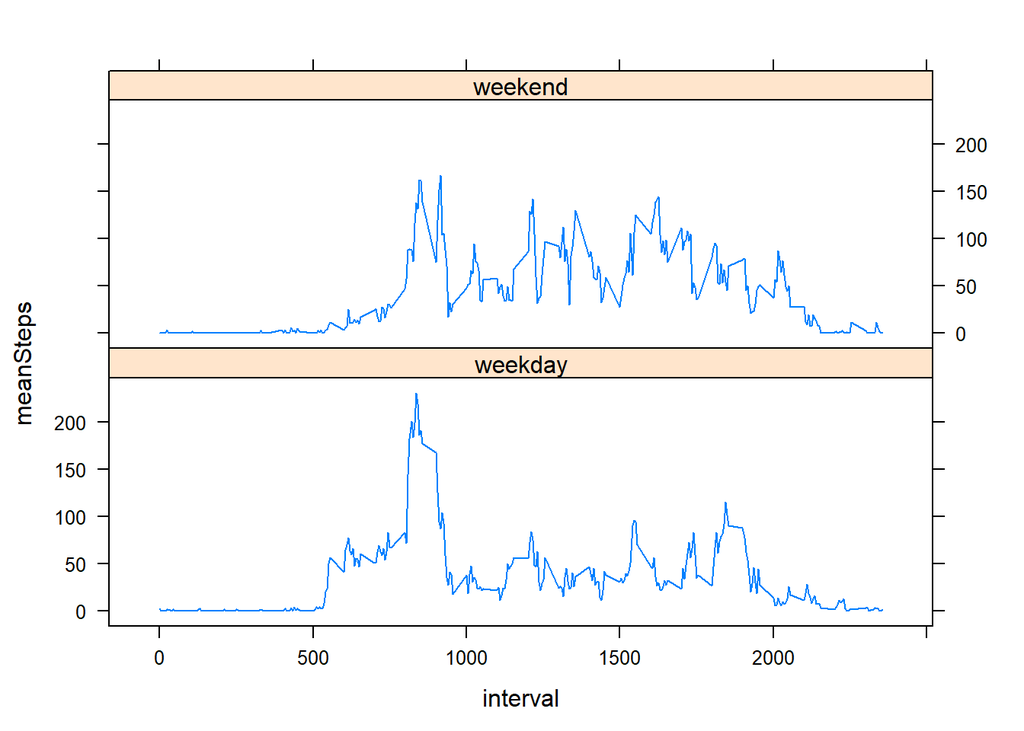

```r
#find out the which day of the week

#find out the which day of the week
activity2$day<-weekdays(as.Date(activity2$date,format="%Y-%m-%d"))

#assign weekend and weekday based on the day of the week
activity2$day[grep("Saturday|Sunday",activity2$day)]<-"weekend"
activity2$day[!grepl("weekend", activity2$day)]<-"weekday"

activity2$day<-as.factor(activity2$day)

intervalstep2<-with(activity2,tapply(steps, list(interval,day), mean))

df2<-data.frame(interval=row.names(intervalstep2),
meanSteps=intervalstep2[,1], day=rep("weekday", nrow(intervalstep2)))

df3<-data.frame(interval=row.names(intervalstep2),
meanSteps=intervalstep2[,2], day=rep("weekend", nrow(intervalstep2)))

final<-rbind(df2,df3)
final$interval<-as.numeric(as.character(final$interval))

library(lattice)

xyplot(meanSteps~interval | day, data=final, type="l", layout=c(1,2))
```

Acitivty patterns between weekend and weekdays have some differences. For example, the average numbers of steps are higher during intervals 800-1000 on the weekdays, compared to the same intervals on the weekends. The average number of steps are higher between intervals 1200-2000 on the weekends, compared to those of same intervals on the weekdays. During the weekends, the average of number of steps across intervals 800-2000 are rather similar. But the average numbers of step are much higher between 800-1000 intervals than the other intervals during the weekdays.